# HW_1

# Number 7

```r
bus_data <- select(zscore,V1,V2,V3,V4,V5,V6,V7,V8,V9,V10,V11,V12,V13,V14,V15,V16,V17,V18, B)
set.seed(123)
sample <- sample.split(bus_data$B, SplitRatio=0.8)

bus_train = subset(bus_data, sample == TRUE)
bus_test = subset(bus_data, sample == FALSE)
```

```
Regression tree:
rpart(formula = B ~ ., data = bus_test, method = "anova")

Variables actually used in tree construction:
[1] V10 V12 V15 V18 V6

Root node error: 32.612/170 = 0.19183

n= 170

        CP nsplit rel error  xerror     xstd
1 0.286683      0   1.00000 1.01709 0.085927
2 0.082370      2   0.42663 0.54112 0.096189
3 0.062368      3   0.34426 0.56993 0.107004
4 0.031354      4   0.28190 0.53857 0.099394
5 0.010000      5   0.25054 0.50106 0.089167
Call:
rpart(formula = B ~ ., data = bus_test, method = "anova")
  n= 170

          CP nsplit rel error    xerror       xstd
1 0.28668262      0 1.0000000 1.0170933 0.08592686
2 0.08236987      2 0.4266348 0.5411228 0.09618903
3 0.06236768      3 0.3442649 0.5699257 0.10700380
4 0.03135378      4 0.2818972 0.5385658 0.09939388
5 0.01000000      5 0.2505434 0.5010609 0.08916687

Variable importance
V12  V3  V6 V11  V7  V8  V9 V10 V18  V1  V2 V13 V14  V4 V16 V15  V5
 14  10  10  10  10  10   8   7   7   4   2   2   1   1   1   1   1

Node number 1: 170 observations,    complexity param=0.2866826
  mean=0.2588235, MSE=0.1918339
  left son=2 (95 obs) right son=3 (75 obs)
  Primary splits:
      V6  < -0.2319769 to the right, improve=0.2807245, (0 missing)
      V14 < 0.806444   to the left,  improve=0.2088595, (0 missing)
      V18 < -0.8243789 to the right, improve=0.1836505, (0 missing)
      V3  < -0.4494587 to the right, improve=0.1435168, (0 missing)
      V11 < 1.747889   to the left,  improve=0.1414141, (0 missing)
```

[output cut: 70 more lines]

```
  Primary splits:
      V15 < 0.2283145  to the right, improve=0.2329032, (0 missing)
      V3  < -0.4494587 to the right, improve=0.1960784, (0 missing)
      V7  < -0.4614003 to the right, improve=0.1608187, (0 missing)
      V11 < -0.2906623 to the right, improve=0.1608187, (0 missing)
      V12 < -0.5116872 to the right, improve=0.1608187, (0 missing)
  Surrogate splits:
      V1  < 1.678494   to the right, agree=0.805, adj=0.2, (0 split)
      V10 < 1.136785   to the right, agree=0.780, adj=0.1, (0 split)

Node number 30: 10 observations
  mean=0.6, MSE=0.24

Node number 31: 31 observations
  mean=0.9677419, MSE=0.03121748
```

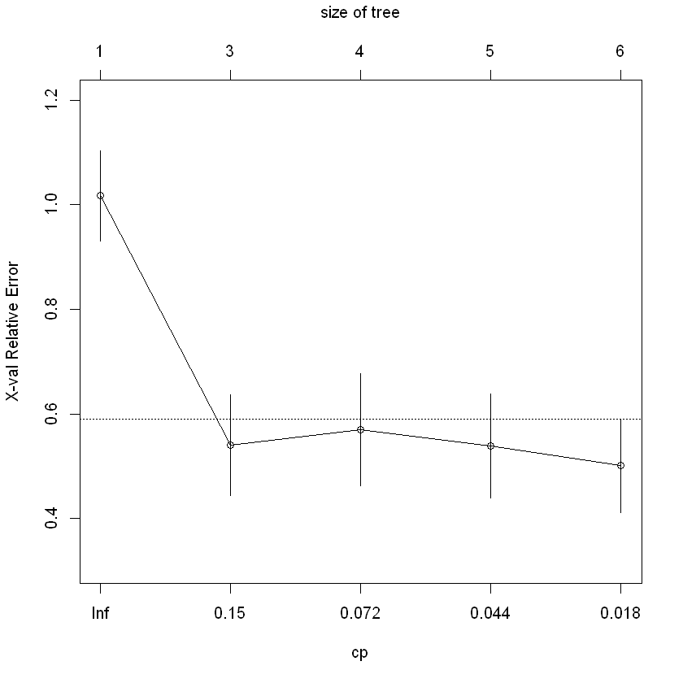

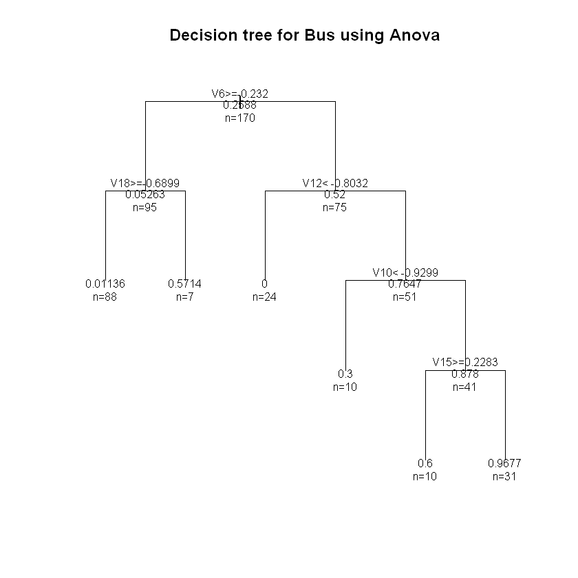

```r
fit <-rpart(B~.,
            method="anova", data=bus_test)
printcp(fit) # display the results
plotcp(fit) # visualize cross-validation results
summary(fit) # detailed summary of splits
plot(fit, uniform=TRUE,
     main="Decision tree for Bus using Anova",margin=0.05)
text(fit, use.n=TRUE, all=TRUE, cex=.8)
```

```r
bus_training_predict <- predict(fit,bus_train)
bus_predict <- predict(fit, bus_test)

tabel_mat_train <-table(bus_train$B,bus_training_predict)
table_mat <- table(bus_test$B, bus_predict)

accuracy_Train <- sum(diag(tabel_mat_train)) / sum(tabel_mat_train)
accuracy_Test <- sum(diag(table_mat)) / sum(table_mat)
print(paste('Accuracy for train', accuracy_Train))
print(paste('Accuracy for test', accuracy_Test))
```

```
[1] "Accuracy for train 0.143491124260355"
[1] "Accuracy for test 0.147058823529412"
```

```
Classification tree:
rpart(formula = B ~ ., data = bus_test, method = "class")

Variables actually used in tree construction:
[1] V10 V12 V18 V6

Root node error: 44/170 = 0.25882

n= 170

        CP nsplit rel error  xerror     xstd
1 0.306818      0   1.00000 1.00000 0.129788
2 0.090909      2   0.38636 0.45455 0.095474
3 0.022727      3   0.29545 0.45455 0.095474
4 0.010000      4   0.27273 0.47727 0.097505
Call:
rpart(formula = B ~ ., data = bus_test, method = "class")
  n= 170

          CP nsplit rel error    xerror       xstd
1 0.30681818      0 1.0000000 1.0000000 0.12978798
2 0.09090909      2 0.3863636 0.4545455 0.09547364
3 0.02272727      3 0.2954545 0.4545455 0.09547364
4 0.01000000      4 0.2727273 0.4772727 0.09750472

Variable importance
V12  V3  V6 V11  V7  V8  V9 V18 V10  V1  V2 V13 V14  V4 V16  V5
 14  11  10  10  10  10   8   7   7   4   2   2   2   1   1   1

Node number 1: 170 observations,    complexity param=0.3068182
  predicted class=0  expected loss=0.2588235  P(node) =1
    class counts:   126    44
   probabilities: 0.741 0.259
  left son=2 (95 obs) right son=3 (75 obs)
  Primary splits:
      V6  < -0.2319769 to the right, improve=18.309850, (0 missing)
      V14 < 0.806444   to the left,  improve=13.622560, (0 missing)
      V18 < -0.8243789 to the right, improve=11.978340, (0 missing)
      V3  < -0.4494587 to the right, improve= 9.360672, (0 missing)
      V8  < -1.463703  to the right, improve= 9.223529, (0 missing)
```

[output cut: 70 more lines]

```
      V2  < -1.031092  to the left,  agree=0.961, adj=0.8, (0 split)
      V13 < -1.066269  to the left,  agree=0.922, adj=0.6, (0 split)
      V16 < 0.6606819  to the right, agree=0.882, adj=0.4, (0 split)
      V18 < 0.7887851  to the right, agree=0.863, adj=0.3, (0 split)
      V14 < -1.06347   to the left,  agree=0.843, adj=0.2, (0 split)

Node number 14: 10 observations
  predicted class=0  expected loss=0.3  P(node) =0.05882353
    class counts:     7     3
   probabilities: 0.700 0.300

Node number 15: 41 observations
  predicted class=1  expected loss=0.1219512  P(node) =0.2411765
    class counts:     5    36
   probabilities: 0.122 0.878
```

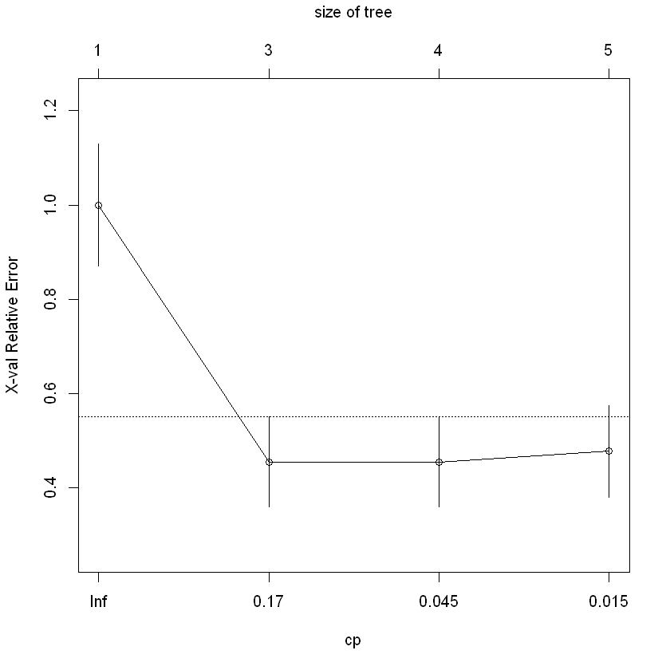

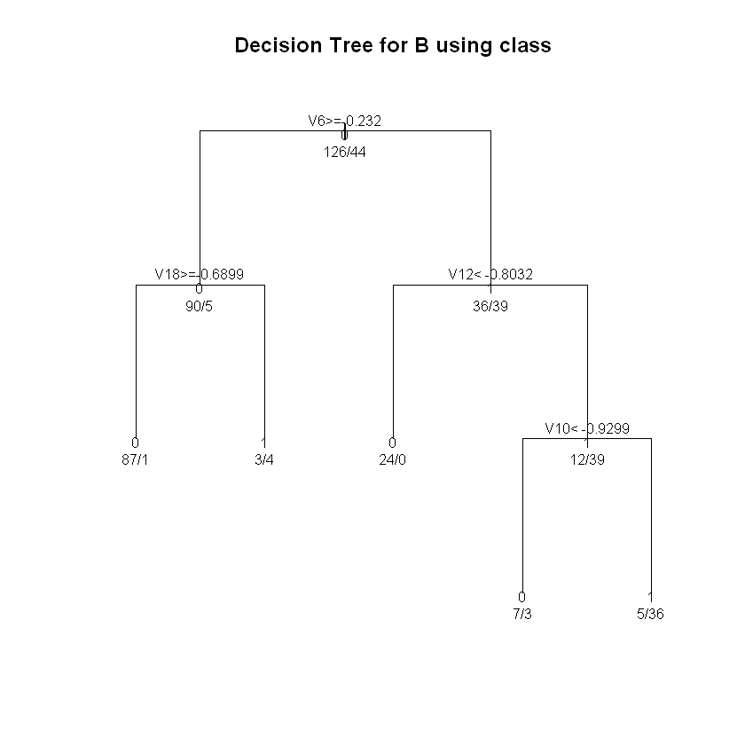

```r
fit <-rpart(B~.,
            method="class", data=bus_test)
printcp(fit) # display the results
plotcp(fit) # visualize cross-validation results
summary(fit) # detailed summary of splits

plot(fit, uniform=TRUE,
     main="Decision Tree for B using class",margin=0.05)
text(fit, use.n=TRUE, all=TRUE, cex=.8)
```

```r
bus_training_predict <- predict(fit,bus_train, type="class")
bus_predict <- predict(fit, bus_test, type="class")

tabel_mat_train <-table(bus_train$B,bus_training_predict)
table_mat <- table(bus_test$B, bus_predict)

accuracy_Train <- sum(diag(tabel_mat_train)) / sum(tabel_mat_train)
accuracy_Test <- sum(diag(table_mat)) / sum(table_mat)
print(paste('Accuracy for train', accuracy_Train))
print(paste('Accuracy for test', accuracy_Test))
```

```
[1] "Accuracy for train 0.914201183431953"
[1] "Accuracy for test 0.929411764705882"
```

```
Rates regression tree:
rpart(formula = B ~ ., data = bus_test, method = "poisson")

Variables actually used in tree construction:
[1] V12 V14 V3  V6

Root node error: 118.94/170 = 0.69966

n= 170

        CP nsplit rel error  xerror     xstd
1 0.328054      0   1.00000 1.01189 0.035010
2 0.281472      1   0.67195 0.90294 0.084565
3 0.094285      2   0.39047 0.56029 0.097329
4 0.027056      4   0.20190 0.46672 0.100847
5 0.010000      5   0.17485 0.45811 0.099922
Call:
rpart(formula = B ~ ., data = bus_test, method = "poisson")
  n= 170

          CP nsplit rel error    xerror       xstd
1 0.32805351      0 1.0000000 1.0118879 0.03501034
2 0.28147178      1 0.6719465 0.9029362 0.08456515
3 0.09428514      2 0.3904747 0.5602883 0.09732926
4 0.02705634      4 0.2019044 0.4667222 0.10084701
5 0.01000000      5 0.1748481 0.4581074 0.09992200

Variable importance
 V7  V3  V9 V12  V6 V11  V8 V10  V2  V5 V14 V18 V17  V4  V1
 15  13  13  11  10  10   8   6   5   4   2   1   1   1   1

Node number 1: 170 observations,    complexity param=0.3280535
  events=44,  estimated rate=0.2588235 , mean deviance=0.6996563
  left son=2 (72 obs) right son=3 (98 obs)
  Primary splits:
      V6  < -0.01464306 to the right, improve=39.54425, (0 missing)
      V11 < -0.8003002  to the left,  improve=21.59954, (0 missing)
      V12 < -0.800324   to the left,  improve=20.94036, (0 missing)
      V14 < 0.806444    to the left,  improve=20.62782, (0 missing)
      V18 < -0.8243789  to the right, improve=19.63493, (0 missing)
```

[output cut: 70 more lines]

```
  Surrogate splits:
      V5  < 0.5458937   to the left,  agree=0.844, adj=0.688, (0 split)
      V7  < -0.4614003  to the right, agree=0.781, adj=0.562, (0 split)
      V9  < -0.4177024  to the right, agree=0.781, adj=0.562, (0 split)
      V11 < -0.3065885  to the right, agree=0.781, adj=0.562, (0 split)
      V12 < -0.3617092  to the right, agree=0.781, adj=0.562, (0 split)

Node number 15: 33 observations
  events=30,  estimated rate=0.8409371 , mean deviance=0.1786713

Node number 28: 16 observations
  events=0,  estimated rate=0.05034325 , mean deviance=0.1006865

Node number 29: 16 observations
  events=13,  estimated rate=0.7048055 , mean deviance=0.3530903
```

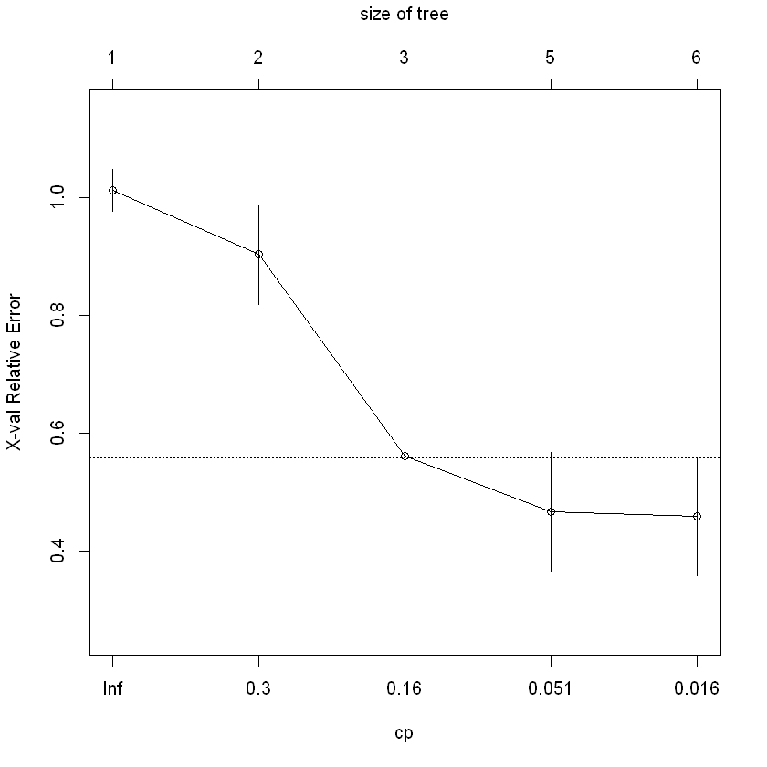

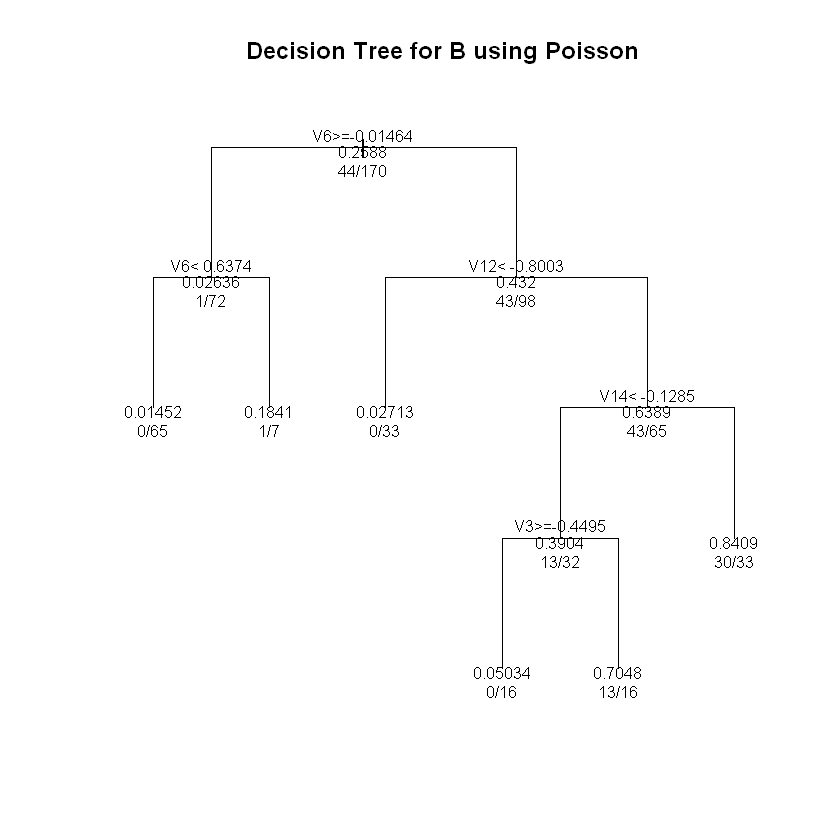

```r
fit <-rpart(B~.,
            method="poisson", data=bus_test)
printcp(fit) # display the results
plotcp(fit) # visualize cross-validation results
summary(fit) # detailed summary of splits

plot(fit, uniform=TRUE,
     main="Decision Tree for B using Poisson",margin=0.05)
text(fit, use.n=TRUE, all=TRUE, cex=.8)
```

```r
bus_training_predict <- predict(fit,bus_train)
bus_predict <- predict(fit, bus_test)

tabel_mat_train <-table(bus_train$B,bus_training_predict)
table_mat <- table(bus_test$B, bus_predict)

accuracy_Train <- sum(diag(tabel_mat_train)) / sum(tabel_mat_train)
accuracy_Test <- sum(diag(table_mat)) / sum(table_mat)
print(paste('Accuracy for train', accuracy_Train))
print(paste('Accuracy for test', accuracy_Test))
```

```
[1] "Accuracy for train 0.368343195266272"
[1] "Accuracy for test 0.382352941176471"
```

```r
van_data <- select(zscore,V1,V2,V3,V4,V5,V6,V7,V8,V9,V10,V11,V12,V13,V14,V15,V16,V17,V18, V)
set.seed(123)
sample <- sample.split(van_data$V, SplitRatio=0.8)

van_train = subset(van_data, sample == TRUE)
van_test = subset(van_data, sample == FALSE)
```

```
Regression tree:
rpart(formula = V ~ ., data = van_test, method = "anova")

Variables actually used in tree construction:
[1] V11 V16 V17 V4  V6  V7

Root node error: 30.533/169 = 0.18067

n= 169

        CP nsplit rel error  xerror     xstd
1 0.333434      0   1.00000 1.01232 0.096516
2 0.174691      1   0.66657 0.74335 0.084245
3 0.108528      2   0.49187 0.59432 0.095242
4 0.035217      3   0.38335 0.62105 0.116721
5 0.013399      5   0.31291 0.63776 0.120068
6 0.010000      6   0.29951 0.65936 0.121273
Call:
rpart(formula = V ~ ., data = van_test, method = "anova")
  n= 169

          CP nsplit rel error    xerror       xstd
1 0.33343426      0 1.0000000 1.0123189 0.09651629
2 0.17469118      1 0.6665657 0.7433502 0.08424520
3 0.10852801      2 0.4918746 0.5943191 0.09524204
4 0.03521724      3 0.3833465 0.6210524 0.11672078
5 0.01339852      5 0.3129121 0.6377587 0.12006769
6 0.01000000      6 0.2995135 0.6593567 0.12127324

Variable importance
V11 V12  V8  V7  V4  V9 V17 V14 V16 V18  V1 V10  V6 V13  V2
 15  12  12  12  11   8   7   5   4   4   4   1   1   1   1

Node number 1: 169 observations,    complexity param=0.3334343
  mean=0.2366864, MSE=0.1806659
  left son=2 (99 obs) right son=3 (70 obs)
  Primary splits:
      V11 < -0.5773336  to the right, improve=0.3334343, (0 missing)
      V8  < 0.2004969   to the left,  improve=0.2721792, (0 missing)
      V12 < -0.3843474  to the right, improve=0.2301606, (0 missing)
```

[output cut: 90 more lines]

```
  Surrogate splits:
      V12 < -0.9220043  to the right, agree=1.000, adj=1.000, (0 split)
      V8  < 0.9685894   to the left,  agree=0.935, adj=0.846, (0 split)
      V11 < -0.9436359  to the right, agree=0.871, adj=0.692, (0 split)
      V13 < -0.2213237  to the right, agree=0.806, adj=0.538, (0 split)
      V2  < -0.8690144  to the right, agree=0.774, adj=0.462, (0 split)

Node number 31: 13 observations
  mean=1, MSE=0

Node number 60: 13 observations
  mean=0.4615385, MSE=0.2485207

Node number 61: 18 observations
  mean=0.8888889, MSE=0.09876543
```

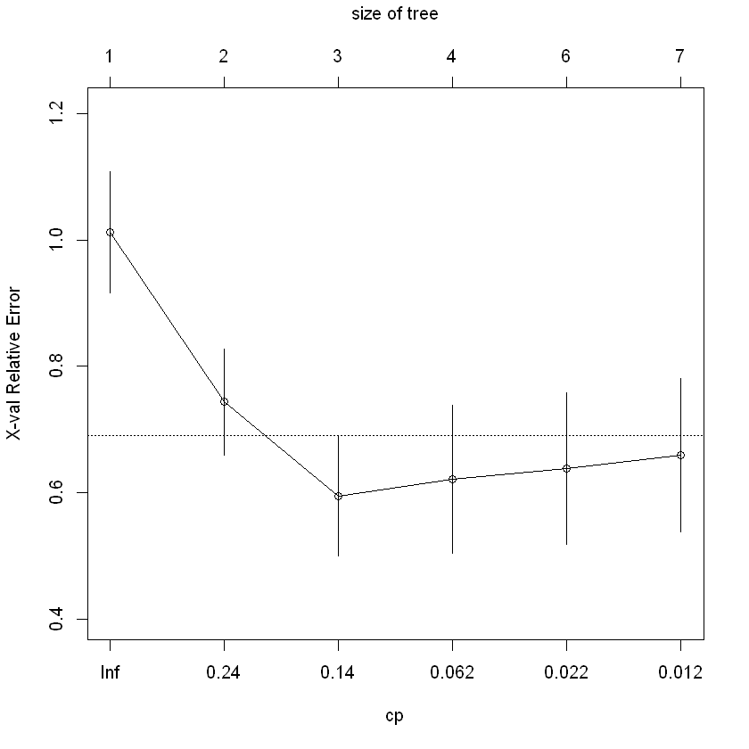

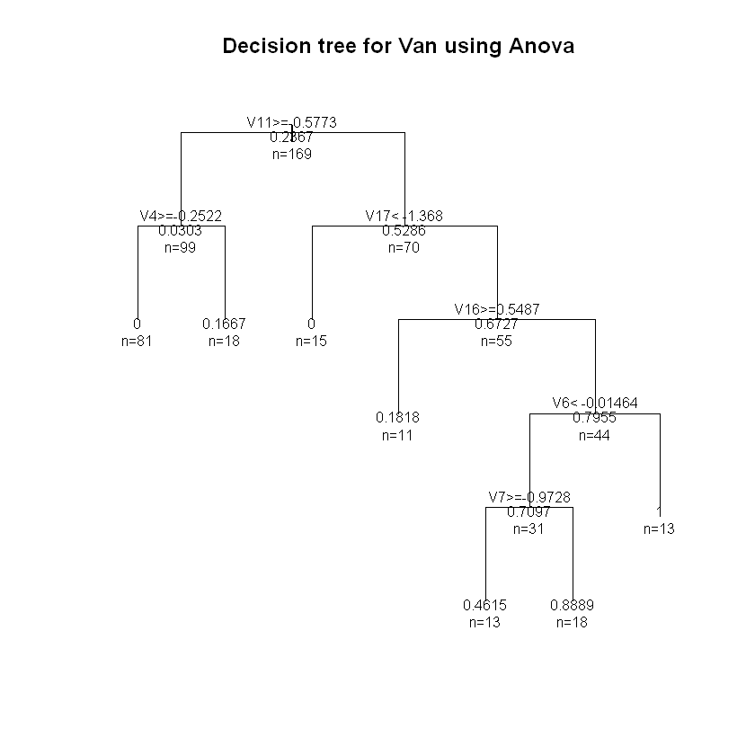

```r
fit <-rpart(V~.,
            method="anova", data=van_test)
printcp(fit) # display the results
plotcp(fit) # visualize cross-validation results
summary(fit) # detailed summary of splits
plot(fit, uniform=TRUE,
     main="Decision tree for Van using Anova",margin=0.05)
text(fit, use.n=TRUE, all=TRUE, cex=.8)
```

```r
van_training_predict <- predict(fit,van_train)
van_predict <- predict(fit, van_test)

tabel_mat_train <-table(van_train$V,van_training_predict)
table_mat <- table(van_test$V, van_predict)

accuracy_Train <- sum(diag(tabel_mat_train)) / sum(tabel_mat_train)
accuracy_Test <- sum(diag(table_mat)) / sum(table_mat)
print(paste('Accuracy for train', accuracy_Train))
print(paste('Accuracy for test', accuracy_Test))
```

```
[1] "Accuracy for train 0.608567208271787"
[1] "Accuracy for test 0.585798816568047"
```

```
Rates regression tree:
rpart(formula = V ~ ., data = van_test, method = "poisson")

Variables actually used in tree construction:
[1] V1  V14 V16 V6  V8

Root node error: 115.28/169 = 0.68214

n= 169

        CP nsplit rel error  xerror     xstd
1 0.420630      0   1.00000 1.00667 0.043063
2 0.169683      1   0.57937 0.71200 0.089058
3 0.056958      2   0.40969 0.62105 0.105755
4 0.053347      3   0.35273 0.64299 0.119267
5 0.043708      4   0.29938 0.60537 0.118670
6 0.010000      6   0.21197 0.54430 0.112637
Call:
rpart(formula = V ~ ., data = van_test, method = "poisson")
  n= 169

          CP nsplit rel error    xerror       xstd
1 0.42062963      0 1.0000000 1.0066725 0.04306341
2 0.16968326      1 0.5793704 0.7120036 0.08905848
3 0.05695812      2 0.4096871 0.6210480 0.10575510
4 0.05334726      3 0.3527290 0.6429871 0.11926711
5 0.04370757      4 0.2993817 0.6053660 0.11867006
6 0.01000000      6 0.2119666 0.5443049 0.11263739

Variable importance
 V8 V12  V4  V7  V9 V11 V14 V18 V17  V1  V3 V16 V10
 15  15  14  13  12  12   5   4   4   3   2   2   1

Node number 1: 169 observations,    complexity param=0.4206296
  events=40,  estimated rate=0.2366864 , mean deviance=0.6821393
  left son=2 (79 obs) right son=3 (90 obs)
  Primary splits:
      V8  < 0.2004969   to the left,  improve=50.40712, (0 missing)
      V11 < -0.4499242  to the right, improve=48.38343, (0 missing)
      V12 < -0.3843474  to the right, improve=44.41502, (0 missing)
```

[output cut: 83 more lines]

```
  Surrogate splits:
      V12 < -0.8767279  to the right, agree=1.00, adj=1.000, (0 split)
      V7  < -0.942676   to the right, agree=0.96, adj=0.857, (0 split)
      V4  < -0.4911809  to the right, agree=0.92, adj=0.714, (0 split)
      V9  < -0.8034842  to the right, agree=0.92, adj=0.714, (0 split)
      V3  < -0.7347829  to the right, agree=0.88, adj=0.571, (0 split)

Node number 63: 23 observations
  events=22,  estimated rate=0.8448118 , mean deviance=0.09919846

Node number 124: 7 observations
  events=0,  estimated rate=0.08908686 , mean deviance=0.1781737

Node number 125: 18 observations
  events=15,  estimated rate=0.71991 , mean deviance=0.3208685
```

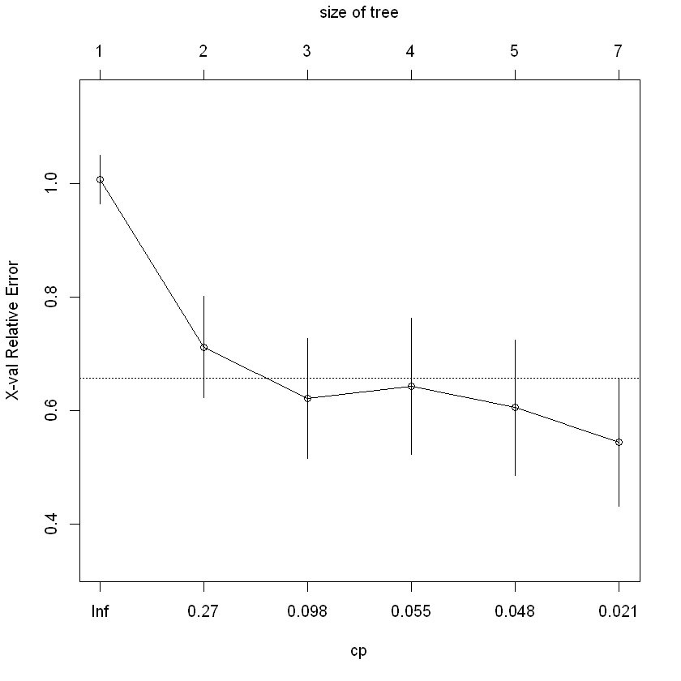

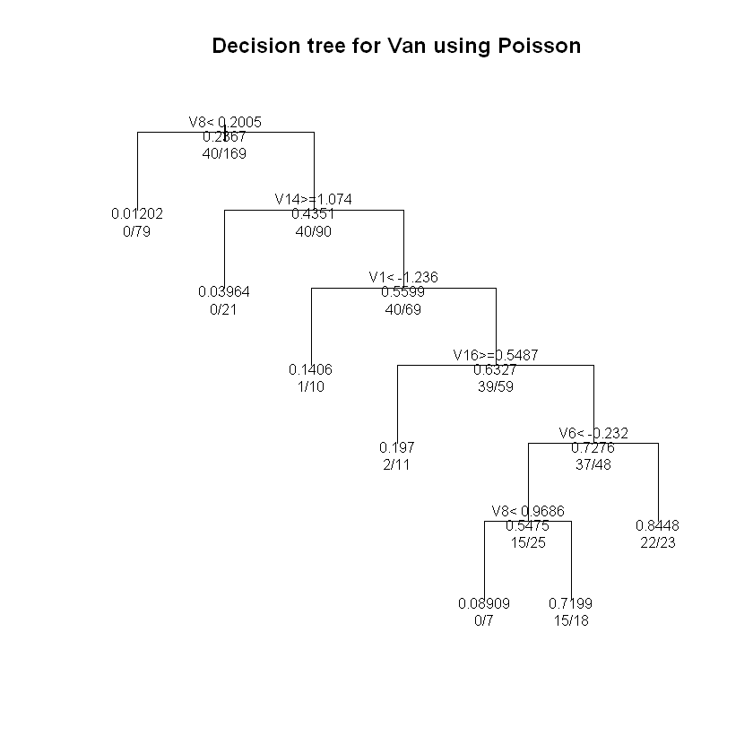

```r
fit <-rpart(V~.,
            method="poisson", data=van_test)
printcp(fit) # display the results
plotcp(fit) # visualize cross-validation results
summary(fit) # detailed summary of splits
plot(fit, uniform=TRUE,
     main="Decision tree for Van using Poisson",margin=0.05)
text(fit, use.n=TRUE, all=TRUE, cex=.8)
```

```r
van_training_predict <- predict(fit,van_train)
van_predict <- predict(fit, van_test)

tabel_mat_train <-table(van_train$V,van_training_predict)
table_mat <- table(van_test$V, van_predict)

accuracy_Train <- sum(diag(tabel_mat_train)) / sum(tabel_mat_train)
accuracy_Test <- sum(diag(table_mat)) / sum(table_mat)
print(paste('Accuracy for train', accuracy_Train))
print(paste('Accuracy for test', accuracy_Test))
```

```
[1] "Accuracy for train 0.511078286558346"
[1] "Accuracy for test 0.467455621301775"
```

```
Classification tree:
rpart(formula = V ~ ., data = van_test, method = "class")

Variables actually used in tree construction:
[1] V11 V16 V17 V6  V7

Root node error: 40/169 = 0.23669

n= 169

      CP nsplit rel error xerror    xstd
1 0.2375      0     1.000  1.000 0.13814
2 0.1750      2     0.525  0.925 0.13440
3 0.0125      3     0.350  0.525 0.10721
4 0.0100      5     0.325  0.550 0.10936
Call:
rpart(formula = V ~ ., data = van_test, method = "class")
  n= 169

      CP nsplit rel error xerror      xstd
1 0.2375      0     1.000  1.000 0.1381407
2 0.1750      2     0.525  0.925 0.1343954
3 0.0125      3     0.350  0.525 0.1072105
4 0.0100      5     0.325  0.550 0.1093621

Variable importance
V11 V12  V7  V8  V4  V9 V17 V14 V16 V18  V1 V10  V6 V13  V2
 15  12  12  12  11   8   7   5   4   4   3   1   1   1   1

Node number 1: 169 observations,    complexity param=0.2375
  predicted class=0  expected loss=0.2366864  P(node) =1
    class counts:   129    40
   probabilities: 0.763 0.237
  left son=2 (99 obs) right son=3 (70 obs)
  Primary splits:
      V11 < -0.5773336  to the right, improve=20.36119, (0 missing)
      V8  < 0.2004969   to the left,  improve=16.62064, (0 missing)
      V12 < -0.3843474  to the right, improve=14.05478, (0 missing)
      V4  < -0.222301   to the right, improve=13.87209, (0 missing)
      V7  < -0.7321179  to the right, improve=13.16265, (0 missing)
```

[output cut: 89 more lines]

```

Node number 31: 13 observations
  predicted class=1  expected loss=0  P(node) =0.07692308
    class counts:     0    13
   probabilities: 0.000 1.000

Node number 60: 13 observations
  predicted class=0  expected loss=0.4615385  P(node) =0.07692308
    class counts:     7     6
   probabilities: 0.538 0.462

Node number 61: 18 observations
  predicted class=1  expected loss=0.1111111  P(node) =0.1065089
    class counts:     2    16
   probabilities: 0.111 0.889
```

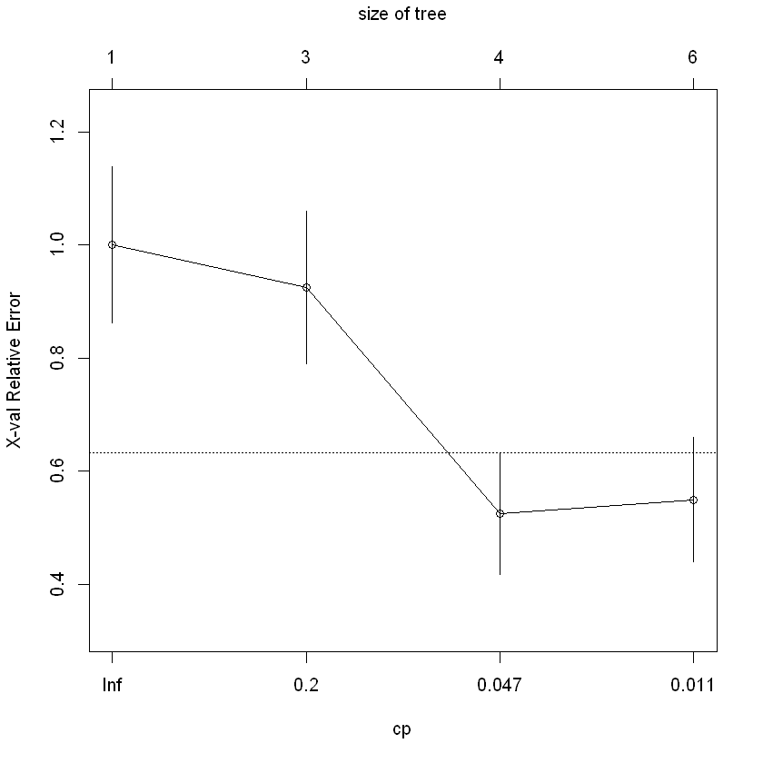

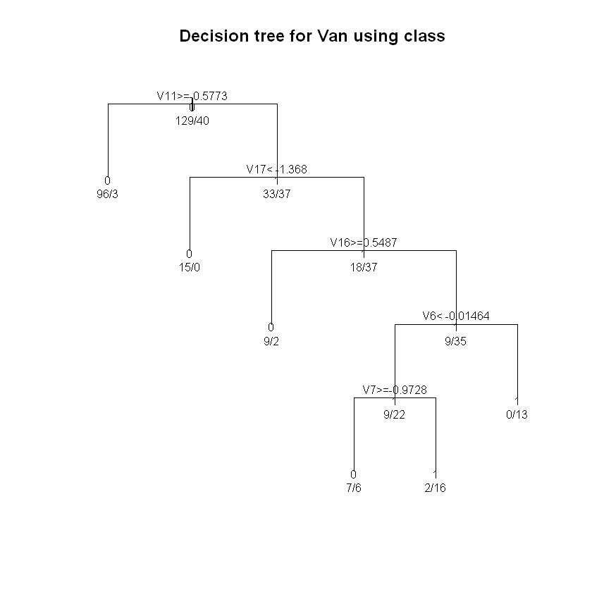

```r
fit <-rpart(V~.,
            method="class", data=van_test)
printcp(fit) # display the results
plotcp(fit) # visualize cross-validation results
summary(fit) # detailed summary of splits
plot(fit, uniform=TRUE,
     main="Decision tree for Van using class",margin=0.05)
text(fit, use.n=TRUE, all=TRUE, cex=.8)
```

```r
van_training_predict <- predict(fit,van_train, type="class")
van_predict <- predict(fit, van_test, type="class")

tabel_mat_train <-table(van_train$V,van_training_predict)
table_mat <- table(van_test$V, van_predict)

accuracy_Train <- sum(diag(tabel_mat_train)) / sum(tabel_mat_train)
accuracy_Test <- sum(diag(table_mat)) / sum(table_mat)
print(paste('Accuracy for train', accuracy_Train))
print(paste('Accuracy for test', accuracy_Test))
```

```
[1] "Accuracy for train 0.846381093057607"
[1] "Accuracy for test 0.923076923076923"
```

### Analysis:

#### Bus Train Result

- Anova method: 0.143491124260355
- Class method: 0.914201183431953
- Poisson method: 0.368343195266272

#### Bus Test Result

- Anova method: 0.147058823529412
- Class method: 0.929411764705882
- Poisson method: 0.382352941176471

From these result for Bus, the Class method model has better accuracy.

The above step can be applied to predict for Van

#### Van Train Result

- Anova method: 0.608567208271787
- Class method: 0.846381093057607
- Poisson method: 0.511078286558346

#### Van Test Result

- Anova method: 0.585798816568047
- Class method: 0.923076923076923
- Poisson method: 0.467455621301775

From these result for Van, the Class method model has better accuracy.

# Number 8

The correlation of the data is very important as it impacts the visualization of everything ranging from question 2 to 5. The data has a more defined pattern/trend when the correlation between the two attributes that we are using has a high correlation. The pattern between circularity and hallow ratio is defined/similar due to its high correlation between each other. Additionally, for the decision tree, we found out using the class method gives you the best accuracy of the decision tree. When it comes to difficulty separating the data and understanding what each attribute means and how it contributes to the dependent variable.

# Number 10

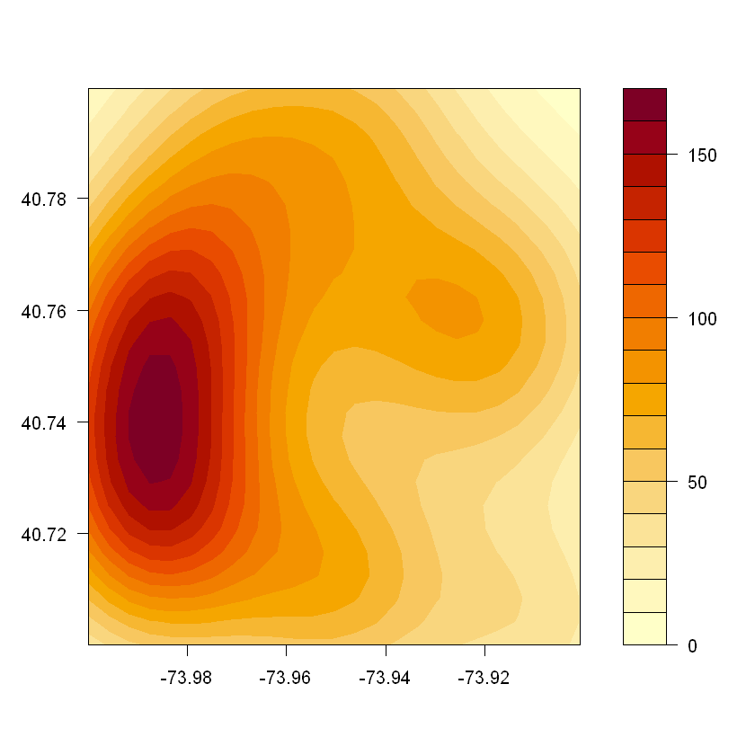

```r
Harassment05 <- read.csv(file="Harassment0-5.csv", header=TRUE, sep=",")
k <- with(Harassment05,MASS:::kde2d(Harassment05$Longitude,Harassment05$Latitude, h = c(0.06, 0.06)))
filled.contour(k)
```

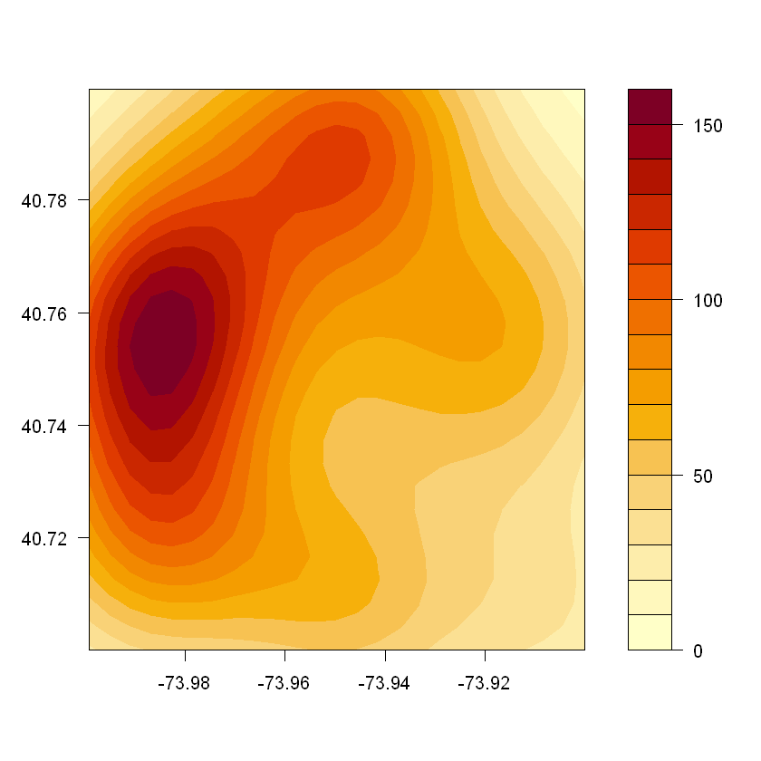

```r
Harassment611 <- read.csv(file="Harassment6-11.csv", header=TRUE, sep=",")
k <- with(Harassment611,MASS:::kde2d(Harassment611$Longitude,Harassment611$Latitude, h = c(0.06, 0.06)))
filled.contour(k)
```

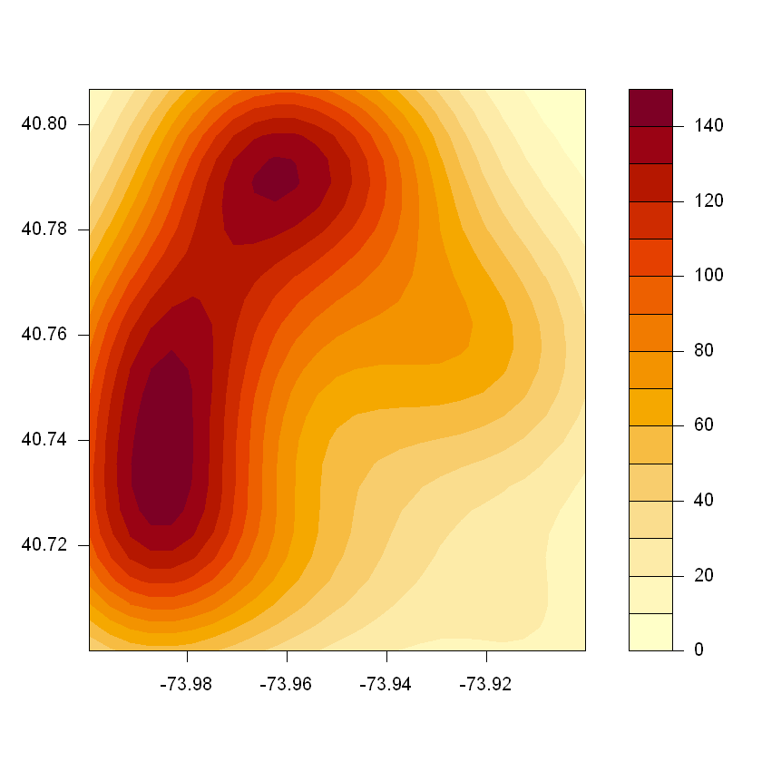

```r
Harassment1217 <- read.csv(file="Harassment12-17.csv", header=TRUE, sep=",")
k <- with(Harassment1217,MASS:::kde2d(Harassment1217$Longitude,Harassment1217$Latitude, h = c(0.06, 0.06)))
filled.contour(k)
```

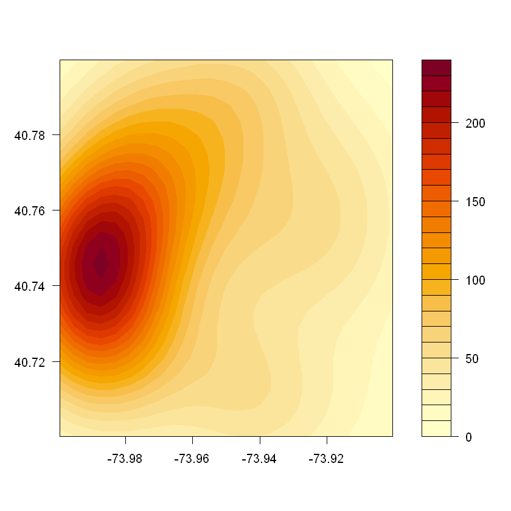

```r
PetitLarcency611 <- read.csv(file="PetitLarcency6-11.csv", header=TRUE, sep=",")
k <- with(PetitLarcency611,MASS:::kde2d(PetitLarcency611$Longitude,PetitLarcency611$Latitude, h = c(0.06, 0.06)))
filled.contour(k)
```

### Analysis:

- For this question, I chose the vector bandwidths of c(0.06, 0.06). This vector bandwidths best fit the series of heatmap I created because the contour lines generated using the bandwidth aligns very well with the data represented on the heatmap.
- This bandwidth created a contour map that is concentrated around the high-volume area on the heat map, but it is ignoring the plots on the map. I incremented the bandwidth by 0.01, this showed improvements in the contour line be align to the points.

# Number 11

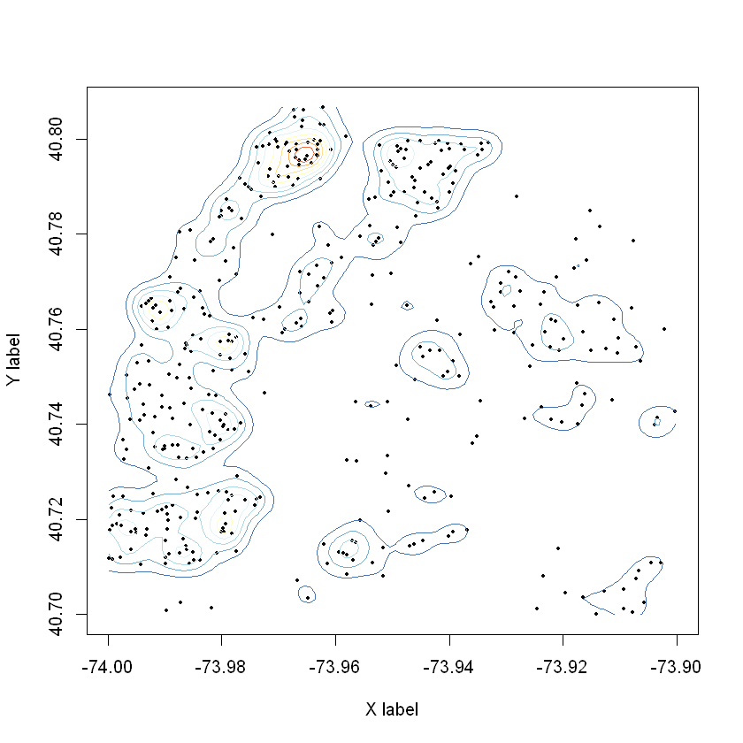

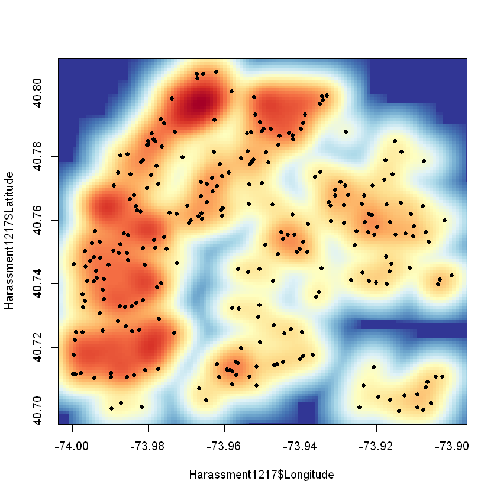

```r
k <- 11
my.cols <- rev(brewer.pal(k, "RdYlBu"))
z <- kde2d(Harassment1217$Longitude,Harassment1217$Latitude , n=100,h = c(0.01, 0.01))

plot(Harassment1217$Longitude,Harassment1217$Latitude, xlab="X label", ylab="Y label", pch=19, cex=.4)
contour(z, drawlabels=FALSE, nlevels=k, col=my.cols, add=TRUE)
smoothScatter(Harassment1217$Longitude,Harassment1217$Latitude, nrpoints=.3*n, colramp=colorRampPalette(my.cols), pch=19, cex=.8)
```

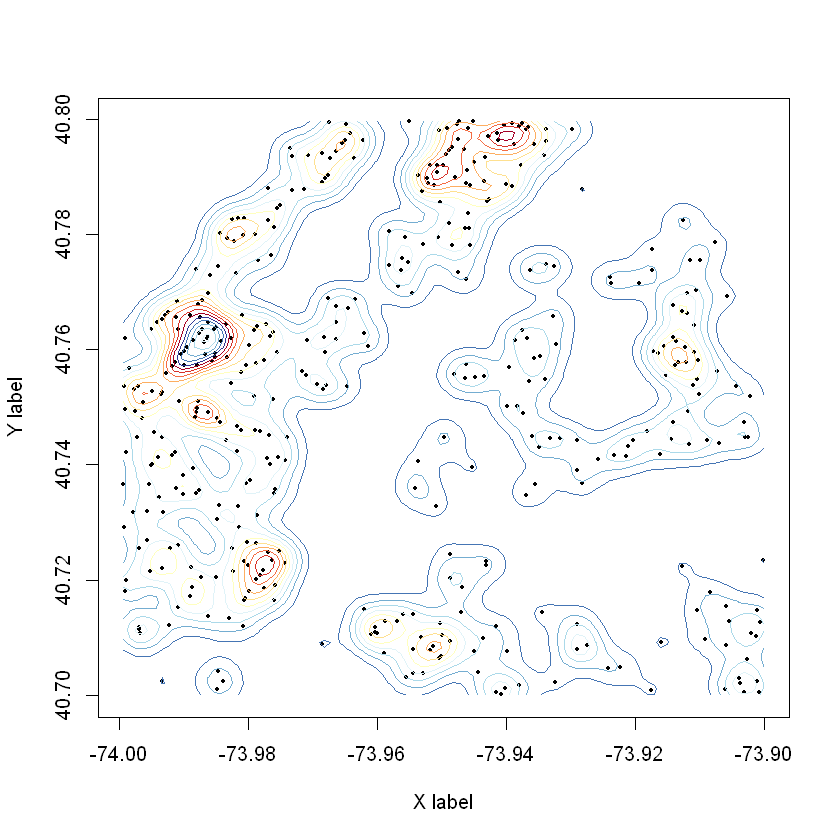

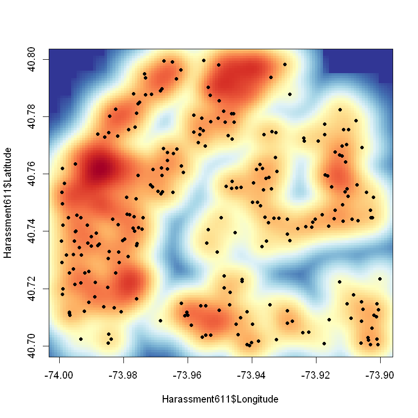

```r
k <- 11
my.cols <- rev(brewer.pal(k, "RdYlBu"))
z <- kde2d(Harassment611$Longitude,Harassment611$Latitude , n=100,h = c(0.01, 0.01))

plot(Harassment611$Longitude,Harassment611$Latitude, xlab="X label", ylab="Y label", pch=19, cex=.4)
contour(z, drawlabels=FALSE, nlevels=k, col=my.cols, add=TRUE)
smoothScatter(Harassment611$Longitude,Harassment611$Latitude, nrpoints=.3*n, colramp=colorRampPalette(my.cols), pch=19, cex=.8)
```

### Analysis:

# Number 12

### Analysis

The highest crime rate area for harassment and petit larceny in 6-11, that is collocated is between the longitude range of -74 to -73.98, and the latitude range of 40.74 to 40.76. The darker spots in those coordinates for both of the heatmaps. The anti collocation for these heatmaps identifies the locations in which crime does not occur in the same areas across the 2 heatmaps. The longitude range of -73.96 to -73.94, and the latitude range 40.78 to 40.80. The areas that had darker hues in one heatmap, but not the other. Meaning in those areas a certain crime was committed increasingly more than the other crime.

# Number 13

- 0-5 and 6-11:
  - During the 0-5 phase we see a high occurrence of crime being committed:
    - the longitude range of -74.00 to -73.96 and the latitude range of 40.70 to 40.80
    - the longitude range of -73.96 to -73.94 and the latitude range of 40.70 t0 40.72
    - the longitude range of -73.95 to -73.91 and the latitude range of 40.71 t0 40.77

We see an upward trend of crime volume being committed at higher latitude around the high crime frequency area of phase 0-5. We can also see that the crimes being committed is a lot more spread out in the later phase of 6-11

- 6-11 and 12-17
  - During the 6-11 phase, we see a trend of crimes being committed at low longitude locations all around the latitude areas. As we progress into the later phase 12-17, we see a gradual shift of crimes/harassments being committed a little bit higher longitude. We can also see less crime being committed at high longitude territory.